# IXN 1 — Exploratory Data Analysis

ANONYMIZED

2023-09-08

```r
#IMPORT (wrangled) data
df_raw <- read_csv("data/CLEAN_UtterancesForAnalysis.csv")

#WRANGLE into DF of coded utterances
#NOT unique utterances, 1 obs for each utterance+detail-code
df_coded <- df_raw %>%
  #rename and factorize cols
  mutate(
    #UNIQUE IDS
    sid = factor(SID), #unique ID for utterance+detail-code
    pid = factor(PID, levels = c( #define level order so happiness first
      #HAPPINESS-FIRST
      "bjs827ee1u", "3r2sh20ei", "4728sjuiz","7ACC0B75","92ghd48xe","iurmer289", "s294hoei",
      #SPACE-FIRST
      "j2719eertu2","lkin27js09b","li832lin23","7382kwtue","E1D39056","8v892iige")),
    #create unique ID for utterances
    uid = factor(as.numeric(factor(paste(pid,factor(Utterance))))), #construct a unique ID for utterances
    #recode lower case and order based on true task order
    TASK = factor(recode(Condition, "Static"="static", "Interactive"="ixn" )),
    TASK = factor(TASK, levels = c("static", "ixn")), #reorder factor levels
    #rename Notebook as DATASET
    DATASET = factor(recode(Notebook, "Happiness"="happiness", "Space"="space")),
    #create temp dataset order var
    data_order = factor(paste(TASK,"_",DATASET)), #create an order var
    data_order = recode(data_order, "ixn _ happiness"="space-first",
                                    "ixn _ space"="happiness-first",
                                    "static _ happiness"="happiness-first",
                                    "static _ space"="space-first"),
    utterance = Utterance,
    reps_group = factor(`group`),
    reps_all = factor(`All representations`),
    #rename flags
    flag_story = `Flag Storytelling`,
    flag_correction = `Flag Correction`,
    flag_simultaneous = `Flag Simultaneous Characterization`,
    #recode and order TOP LEVEL CODES
    code_topic = factor(Highlevel),
    code_topic = recode(code_topic, "ANALYSIS PROCESS" = "PROCESS"),
    code_topic = factor(code_topic, levels = c("PROCESS","DATASET","VARIABLE","RELATIONSHIP")),
    code_datatype = factor(`Data Type`),
    code_detail = factor(`Utterance Type`),
    timestamp = adj_timestamp,
    ixn = factor(interaction_used), #was interaction used?
    PNUM = factor(PNUM,levels = c("P6", "P9", "P10", "P2", "P4", "P12","P13",
                                   "P5", "P7", "P8", "P3", "P1","P11")),

    ) %>%
  select(sid,pid,PNUM,uid,TASK,DATASET,timestamp,ixn,code_topic,code_detail,code_datatype,
         flag_story, flag_correction, flag_simultaneous, utterance, reps_group, reps_all, data_order) %>%
  arrange(data_order)

#REPLACE NA in logicals to FALSE
df_coded$flag_story[is.na(df_coded$flag_story)] <- FALSE
df_coded$flag_correction[is.na(df_coded$flag_correction)] <- FALSE
df_coded$flag_simultaneous[is.na(df_coded$flag_simultaneous)] <- FALSE



#CALCULATE RELATIVE TASK TIMES
df_time <- df_coded %>% mutate(
  time = hms::as_hms(timestamp)
) %>% group_by(pid, TASK) %>%
  # dplyr::summarise( .groups="keep",
  mutate(
    task_start = hms::as_hms(min(time)),
    task_end = hms::as_hms(max(time)),
    task_mins = round(difftime(task_end,task_start, units="mins"),1),
    task_second = task_end - task_start,
    relative_time = timestamp-task_start,
    rel_time = as.double(relative_time)
  ) %>% ungroup() %>% select(pid,PNUM, code_topic,TASK,DATASET,timestamp,task_start,relative_time,rel_time)
```

**There are 742 rows in the `df_coded` dataset, where each row represents an utterance coding (i.e. utterance + detail code). There are 662 *unique* utterances. The difference indicates utterances that were *dual-coded* (i.e. two detail-level codes). No more than two codes were applied to a single utterance. For the purposes of analysis, dual-coded utterances will be treated as two utterances, as they have two distinct (but lexically insepeperable) units of meaning.

# 1 DATA PROFILE

```r
df_coded%>% summarytools::dfSummary(
             plain.ascii  = FALSE,
             graph.magnif = 0.75,
             style        = "grid",
             tmp.img.dir  = "temp",
             missing.col = FALSE,
             method = "render"
)
```

### 1.0.1 Data Frame Summary

#### 1.0.1.1 df_coded

**Dimensions:** 742 x 18  
**Duplicates:** 0

No

Variable

Stats / Values

Freqs (% of Valid)

Graph

Valid

Missing

1

sid  
[factor]

1. 0  
2. 1  
3. 2  
4. 3  
5. 4  
6. 5  
7. 6  
8. 7  
9. 8  
10. 9  
[ 732 others ]

1 ( 0.1%)  
1 ( 0.1%)  
1 ( 0.1%)  
1 ( 0.1%)  
1 ( 0.1%)  
1 ( 0.1%)  
1 ( 0.1%)  
1 ( 0.1%)  
1 ( 0.1%)  
1 ( 0.1%)  
732 (98.7%)

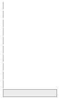

742  
(100.0%)

0  
(0.0%)

2

pid  
[factor]

1. bjs827ee1u  
2. 3r2sh20ei  
3. 4728sjuiz  
4. 7ACC0B75  
5. 92ghd48xe  
6. iurmer289  
7. s294hoei  
8. j2719eertu2  
9. lkin27js09b  
10. li832lin23  
[ 3 others ]

29 ( 3.9%)  
103 (13.9%)  
43 ( 5.8%)  
28 ( 3.8%)  
56 ( 7.5%)  
87 (11.7%)  
88 (11.9%)  
82 (11.1%)  
48 ( 6.5%)  
51 ( 6.9%)  
127 (17.1%)

742  
(100.0%)

0  
(0.0%)

3

PNUM  
[factor]

1. P6  
2. P9  
3. P10  
4. P2  
5. P4  
6. P12  
7. P13  
8. P5  
9. P7  
10. P8  
[ 3 others ]

29 ( 3.9%)  
103 (13.9%)  
43 ( 5.8%)  
28 ( 3.8%)  
56 ( 7.5%)  
87 (11.7%)  
88 (11.9%)  
82 (11.1%)  
48 ( 6.5%)  
51 ( 6.9%)  
127 (17.1%)

742  
(100.0%)

0  
(0.0%)

4

uid  
[factor]

1. 1  
2. 2  
3. 3  
4. 4  
5. 5  
6. 6  
7. 7  
8. 8  
9. 9  
10. 10  
[ 652 others ]

2 ( 0.3%)  
1 ( 0.1%)  
1 ( 0.1%)  
1 ( 0.1%)  
1 ( 0.1%)  
1 ( 0.1%)  
1 ( 0.1%)  
2 ( 0.3%)  
1 ( 0.1%)  
1 ( 0.1%)  
730 (98.4%)

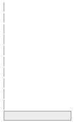

742  
(100.0%)

0  
(0.0%)

5

TASK  
[factor]

1. static  
2. ixn

396 (53.4%)  
346 (46.6%)

742  
(100.0%)

0  
(0.0%)

6

DATASET  
[factor]

1. happiness  
2. space

424 (57.1%)  
318 (42.9%)

742  
(100.0%)

0  
(0.0%)

7

timestamp  
[hms, difftime]

min : 622  
med : 2857  
max : 6900  
units : secs

622 distinct values

742  
(100.0%)

0  
(0.0%)

8

ixn  
[factor]

1. FALSE  
2. TRUE

633 (85.3%)  
109 (14.7%)

742  
(100.0%)

0  
(0.0%)

9

code_topic  
[factor]

1. PROCESS  
2. DATASET  
3. VARIABLE  
4. RELATIONSHIP

160 (21.6%)  
176 (23.7%)  
122 (16.4%)  
284 (38.3%)

742  
(100.0%)

0  
(0.0%)

10

code_detail  
[factor]

1. data orientation  
2. data provenance  
3. data size  
4. distribution outlier (var  
5. distribution range [min,  
6. distribution shape [shape  
7. distribution variance (sd  
8. missing data  
9. outlier (relationship)  
10. plan of action  
[ 8 others ]

16 ( 2.2%)  
11 ( 1.5%)  
9 ( 1.2%)  
9 ( 1.2%)  
33 ( 4.4%)  
79 (10.6%)  
1 ( 0.1%)  
76 (10.2%)  
20 ( 2.7%)  
52 ( 7.0%)  
436 (58.8%)

742  
(100.0%)

0  
(0.0%)

11

code_datatype  
[factor]

1. distribution (continuous  
2. distribution (categorical  
3. relationship (categorical  
4. relationship (categorical  
5. relationship (continuous  
6. relationship (multivariat

76 (17.8%)  
54 (12.7%)  
28 ( 6.6%)  
55 (12.9%)  
146 (34.3%)  
67 (15.7%)

426  
(57.4%)

316  
(42.6%)

12

flag_story  
[logical]

1. FALSE  
2. TRUE

700 (94.3%)  
42 ( 5.7%)

742  
(100.0%)

0  
(0.0%)

13

flag_correction  
[logical]

1. FALSE  
2. TRUE

733 (98.8%)  
9 ( 1.2%)

742  
(100.0%)

0  
(0.0%)

14

flag_simultaneous  
[logical]

1. FALSE  
2. TRUE

682 (91.9%)  
60 ( 8.1%)

742  
(100.0%)

0  
(0.0%)

15

utterance  
[character]

2 ( 0.3%)  
2 ( 0.3%)  
2 ( 0.3%)  
2 ( 0.3%)  
2 ( 0.3%)  
2 ( 0.3%)  
2 ( 0.3%)  
2 ( 0.3%)  
2 ( 0.3%)  
2 ( 0.3%)  
722 (97.3%)

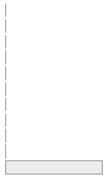

742  
(100.0%)

0  
(0.0%)

16

reps_group  
[factor]

1. barplot  
2. columns  
3. columns_data_dictionary  
4. data_dictionary  
5. data_dictionary_dataframe  
6. data_dictionary_describe  
7. dataframe  
8. dataframe_describe  
9. dataframe_heatmap  
10. dataframe_pairplot  
[ 15 others ]

16 ( 2.2%)  
4 ( 0.5%)  
1 ( 0.1%)  
59 ( 8.0%)  
1 ( 0.1%)  
10 ( 1.3%)  
80 (10.8%)  
1 ( 0.1%)  
1 ( 0.1%)  
1 ( 0.1%)  
568 (76.5%)

742  
(100.0%)

0  
(0.0%)

17

reps_all  
[factor]

1. affect_corruption_brush_7  
2. Age_CryoSleep_scatterplot  
3. age_CryoSleep_ShoppingMal  
4. Age_RoomService_scatterpl  
5. age_roomservice_scatterpl  
6. Age_RoomService_scatterpl  
7. Age_ShoppingMall_scatterp  
8. altair_profile_contVars_j  
9. alx_barplot_df_homeplanet  
10. alx_barplot_df_homeplanet  
[ 245 others ]

4 ( 0.6%)  
3 ( 0.4%)  
1 ( 0.1%)  
1 ( 0.1%)  
1 ( 0.1%)  
1 ( 0.1%)  
1 ( 0.1%)  
1 ( 0.1%)  
2 ( 0.3%)  
1 ( 0.1%)  
693 (97.7%)

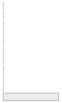

709  
(95.6%)

33  
(4.4%)

18

data_order  
[factor]

1. space-first  
2. happiness-first

308 (41.5%)  
434 (58.5%)

742  
(100.0%)

0  
(0.0%)

# 2 UTTERANCES

## 2.1 by TASK

```r
print("BY TASK")
```

[1] “BY TASK”

```r
freq(df_coded$TASK,
     cumul      = FALSE,
     headings   = FALSE,
     report.nas = FALSE,
     plain.ascii = FALSE)
```

|  | Freq | % |
| --- | --- | --- |
| **static** | 396 | 53.37 |
| **ixn** | 346 | 46.63 |
| **Total** | 742 | 100.00 |

## 2.2 by TASK and DATASET

```r
#COUNT BY TASK AND DATASET
ctable(x = df_coded$TASK,
       y = df_coded$DATASET,
       prop = "t")
```

Cross-Tabulation, Total Proportions  
TASK * DATASET  
Data Frame: df_coded

|  | DATASET | happiness | space | Total |
| --- | --- | --- | --- | --- |
| TASK |  |  |  |  |
| static |  | 256 (34.5%) | 140 (18.9%) | 396 ( 53.4%) |
| ixn |  | 168 (22.6%) | 178 (24.0%) | 346 ( 46.6%) |
| Total |  | 424 (57.1%) | 318 (42.9%) | 742 (100.0%) |

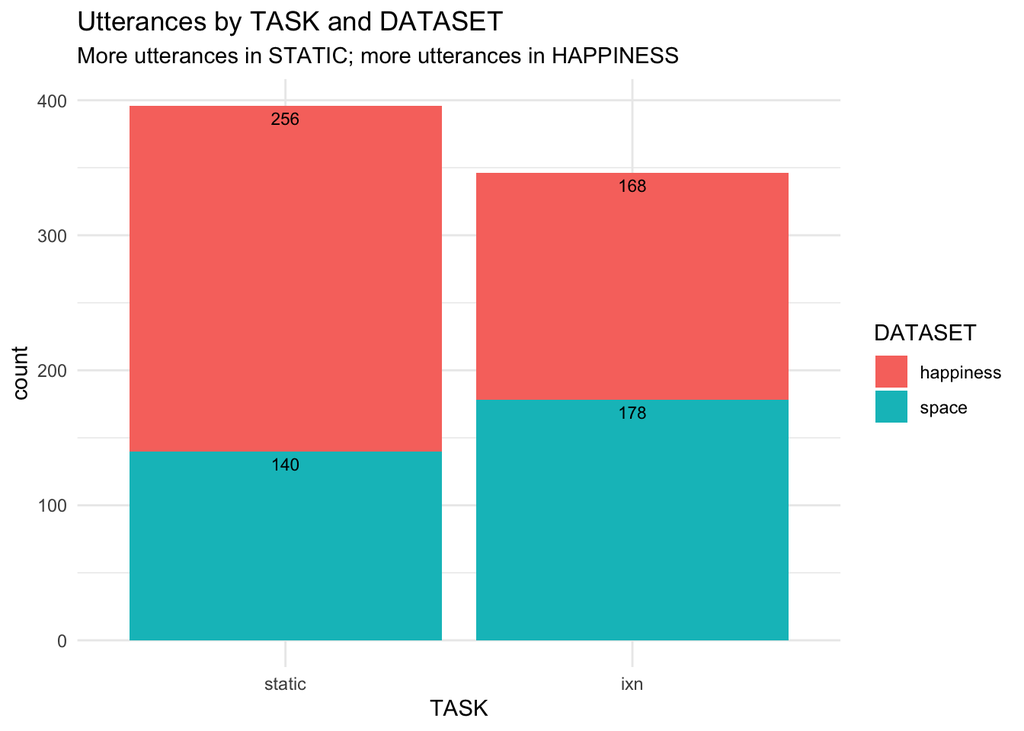

```r
#DF SUMMARIZED BY TASK + DATASET
df_summary <- df_coded %>%
  group_by(TASK,DATASET) %>%
  dplyr::summarise(
    c = n()
  )

#STACKED BAR BY TASK
ggplot(df_summary, aes(x = TASK, y=c, fill= DATASET)) +
  geom_col() +
  geom_text(aes(label=c), size = 3, hjust = 0.5, vjust = 1.5, position = "stack") +
  # scale_fill_brewer(type="qual", palette = 4) +
  labs( title = "Utterances by TASK and DATASET",
        subtitle = "More utterances in STATIC; more utterances in HAPPINESS",
        x= "TASK", y = "count") + theme_minimal()
```

```r
# + theme(legend.position = "blank")
```

## 2.3 by PARTICIPANT

```r
#COUNT BY PARTICIPANT AND TASK
ctable(x = df_coded$PNUM,
       y = df_coded$TASK,
       prop = "r")
```

Cross-Tabulation, Row Proportions  
PNUM * TASK  
Data Frame: df_coded

|  | TASK | static | ixn | Total |
| --- | --- | --- | --- | --- |
| PNUM |  |  |  |  |
| P6 |  | 11 (37.9%) | 18 (62.1%) | 29 (100.0%) |
| P9 |  | 63 (61.2%) | 40 (38.8%) | 103 (100.0%) |
| P10 |  | 30 (69.8%) | 13 (30.2%) | 43 (100.0%) |
| P2 |  | 18 (64.3%) | 10 (35.7%) | 28 (100.0%) |
| P4 |  | 28 (50.0%) | 28 (50.0%) | 56 (100.0%) |
| P12 |  | 46 (52.9%) | 41 (47.1%) | 87 (100.0%) |
| P13 |  | 60 (68.2%) | 28 (31.8%) | 88 (100.0%) |
| P5 |  | 33 (40.2%) | 49 (59.8%) | 82 (100.0%) |
| P7 |  | 29 (60.4%) | 19 (39.6%) | 48 (100.0%) |
| P8 |  | 17 (33.3%) | 34 (66.7%) | 51 (100.0%) |
| P3 |  | 24 (44.4%) | 30 (55.6%) | 54 (100.0%) |
| P1 |  | 10 (40.0%) | 15 (60.0%) | 25 (100.0%) |
| P11 |  | 27 (56.2%) | 21 (43.8%) | 48 (100.0%) |
| Total |  | 396 (53.4%) | 346 (46.6%) | 742 (100.0%) |

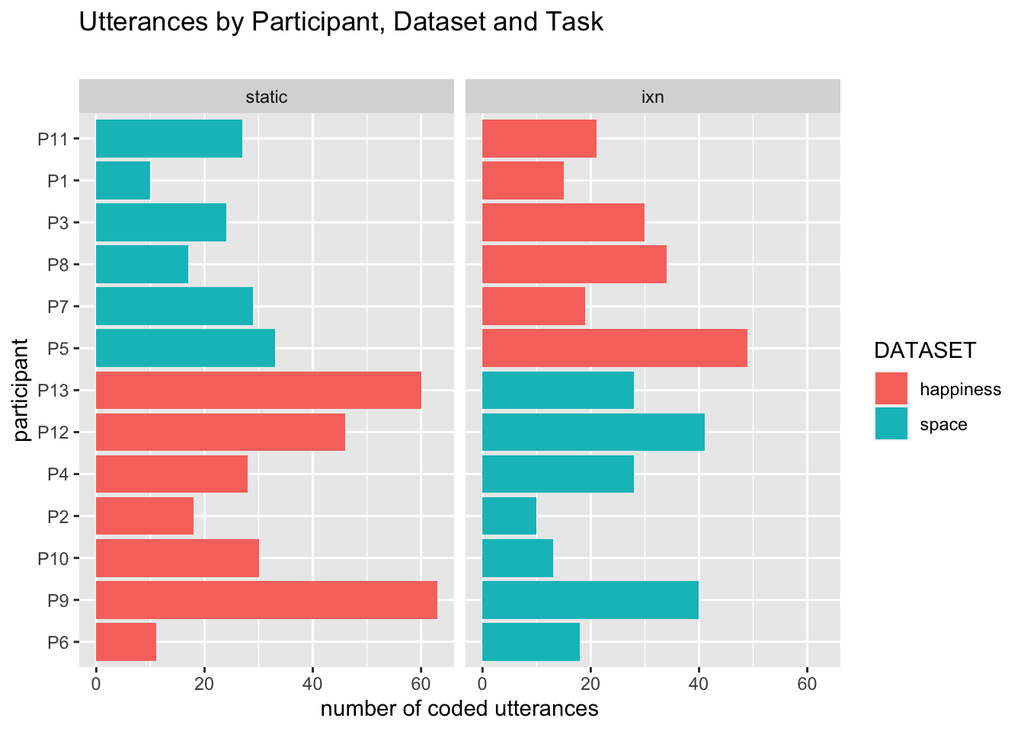

```r
#UTTERANCES by PARTICPANT facet TASK
gf_bar( PNUM ~., fill = ~ DATASET, data = df_coded) %>%
  gf_facet_grid(.~TASK) +
  labs(
    title = "Utterances by Participant, Dataset and Task",
    subtitle = "",
    x = "number of coded utterances",
    y = "participant",
    fill = "DATASET"
  )
```

## 2.4 by TIME

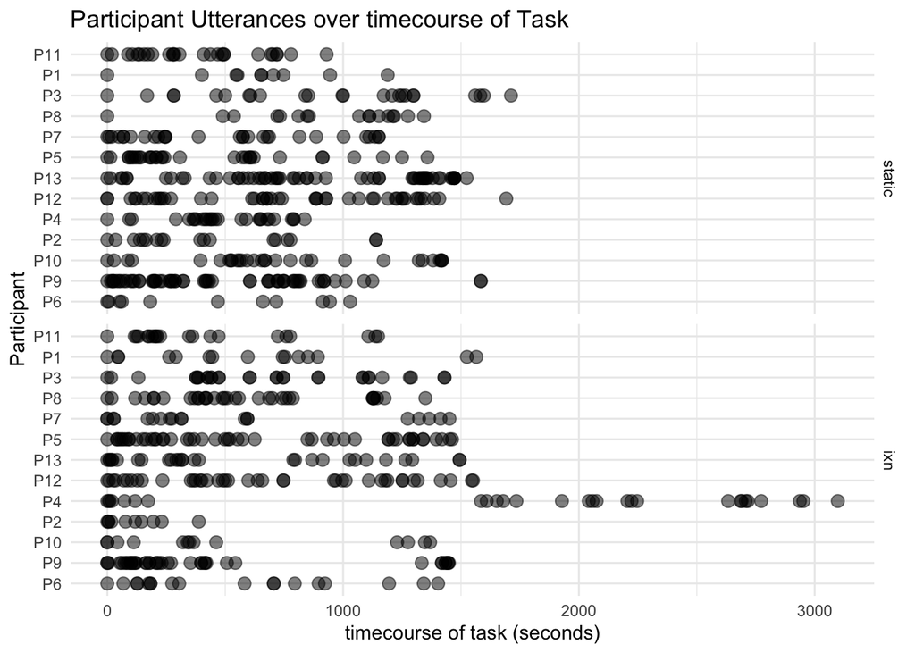

```r
#DOTPLOT
ggplot(df_time, aes(x=rel_time, y = PNUM)) +
  geom_point(alpha=0.5, size=3) +
  facet_grid(df_time$TASK) +
  scale_color_brewer(type="qual", palette = 3) +
  theme_minimal() + labs(
    title = "Participant Utterances over timecourse of Task",
    x= "timecourse of task (seconds)", y = "Participant",
    color = "Topic"
  )
```

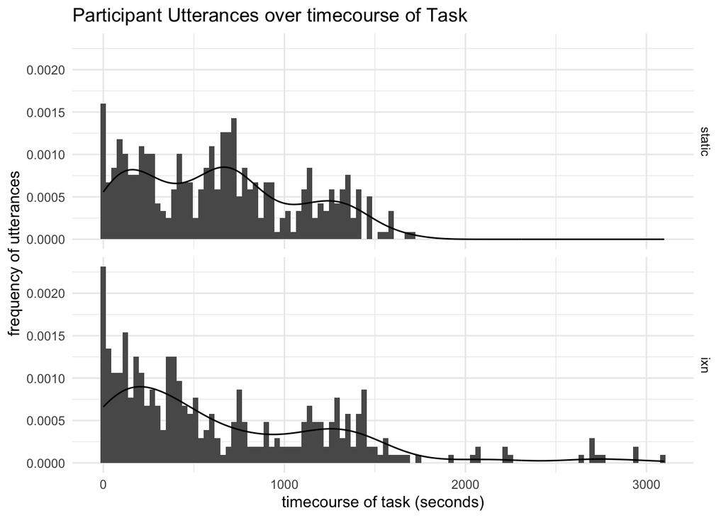

```r
#HISTOGRAMS BY TASK
ggplot(df_time, aes(x = rel_time)) +
  geom_histogram(binwidth = 30,aes(y=..density..)) +
  geom_density()+
  facet_grid(df_time$TASK) +
  theme_minimal() + labs(
    title = "Participant Utterances over timecourse of Task",
    x= "timecourse of task (seconds)", y = "frequency of utterances",
  ) + theme_minimal() + theme(legend.position = "blank")
```

# 3 TOP-CODE

## 3.1 by TASK

```r
#COUNT BY TASK
ctable(x = df_coded$code_topic,
       y = df_coded$TASK,
       prop = "r")
```

Cross-Tabulation, Row Proportions  
code_topic * TASK  
Data Frame: df_coded

|  | TASK | static | ixn | Total |
| --- | --- | --- | --- | --- |
| code_topic |  |  |  |  |
| PROCESS |  | 92 (57.5%) | 68 (42.5%) | 160 (100.0%) |
| DATASET |  | 99 (56.2%) | 77 (43.8%) | 176 (100.0%) |
| VARIABLE |  | 76 (62.3%) | 46 (37.7%) | 122 (100.0%) |
| RELATIONSHIP |  | 129 (45.4%) | 155 (54.6%) | 284 (100.0%) |
| Total |  | 396 (53.4%) | 346 (46.6%) | 742 (100.0%) |

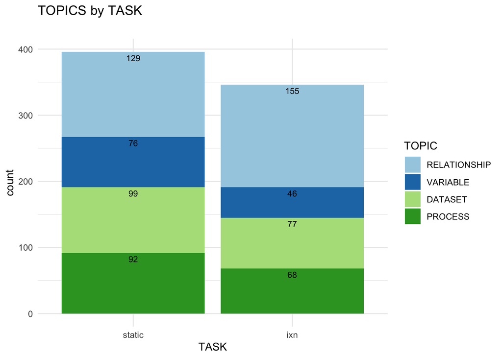

```r
#DF SUMMARIZED BY TASK + DATASET
df_summary <- df_coded %>%
  group_by(code_topic, TASK) %>%
  dplyr::summarise(
    c = n()
  )

#STACKED BAR BY TASK
ggplot(df_summary, aes(x = TASK, y=c, fill= fct_rev(code_topic))) +
  geom_col() +
  geom_text(aes(label=c), size = 3, hjust = 0.5, vjust = 1.5, position = "stack") +
  scale_fill_brewer(type="qual", palette = 3) +
  labs( title = "TOPICS by TASK",
        subtitle = "",
        x= "TASK", y = "count", fill="TOPIC") + theme_minimal()
```

```r
# + theme(legend.position = "blank")
```

## 3.2 by TASK and DATASET

```r
#COUNT BY TASK AND DATASET
table(df_coded$code_topic, df_coded$TASK, df_coded$DATASET) %>% addmargins()
```

, , = happiness

```
           static ixn Sum
```

PROCESS 70 30 100 DATASET 53 29 82 VARIABLE 51 9 60 RELATIONSHIP 82 100 182 Sum 256 168 424

, , = space

```
           static ixn Sum
```

PROCESS 22 38 60 DATASET 46 48 94 VARIABLE 25 37 62 RELATIONSHIP 47 55 102 Sum 140 178 318

, , = Sum

```
           static ixn Sum
```

PROCESS 92 68 160 DATASET 99 77 176 VARIABLE 76 46 122 RELATIONSHIP 129 155 284 Sum 396 346 742

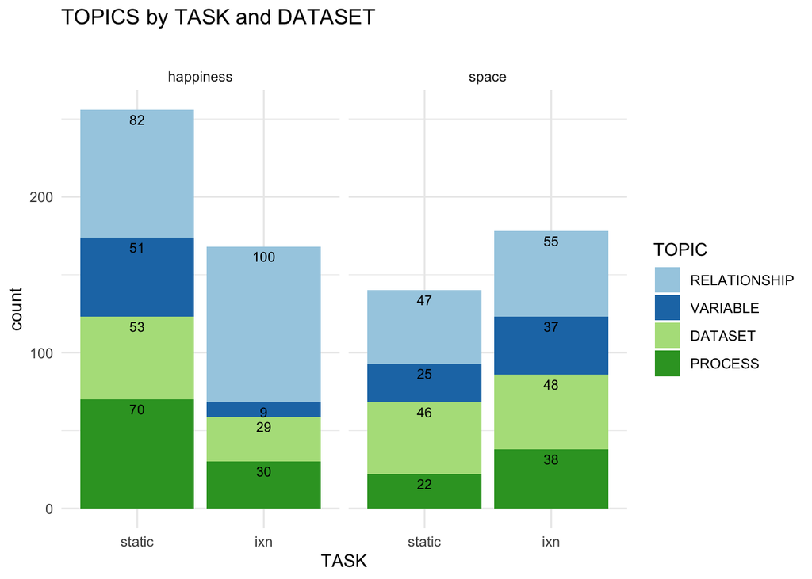

```r
#DF SUMMARIZED BY TASK + DATASET
df_summary <- df_coded %>%
  group_by(code_topic, TASK,DATASET) %>%
  dplyr::summarise(
    c = n()
  )

#STACKED BAR BY TASK FACET DATASET
ggplot(df_summary, aes(x = TASK, y=c, fill= fct_rev(code_topic))) +
  facet_wrap(df_summary$DATASET) +
  geom_col() +
  geom_text(aes(label=c), size = 3, hjust = 0.5, vjust = 1.5, position = "stack") +
  scale_fill_brewer(type="qual", palette = 3) +
  labs( title = "TOPICS by TASK and DATASET",
        subtitle = "",
        x= "TASK", y = "count", fill="TOPIC") + theme_minimal()
```

```r
# + theme(legend.position = "blank")
```

## 3.3 by PARTICIPANT

```r
#COUNT BY PARTICIPANT
ctable(x = df_coded$PNUM,
       y = df_coded$code_topic,
       prop = "r")
```

Cross-Tabulation, Row Proportions  
PNUM * code_topic  
Data Frame: df_coded

|  | code_topic | PROCESS | DATASET | VARIABLE | RELATIONSHIP | Total |
| --- | --- | --- | --- | --- | --- | --- |
| PNUM |  |  |  |  |  |  |
| P6 |  | 6 (20.7%) | 5 (17.2%) | 5 (17.2%) | 13 (44.8%) | 29 (100.0%) |
| P9 |  | 19 (18.4%) | 36 (35.0%) | 23 (22.3%) | 25 (24.3%) | 103 (100.0%) |
| P10 |  | 8 (18.6%) | 11 (25.6%) | 8 (18.6%) | 16 (37.2%) | 43 (100.0%) |
| P2 |  | 3 (10.7%) | 8 (28.6%) | 16 (57.1%) | 1 ( 3.6%) | 28 (100.0%) |
| P4 |  | 10 (17.9%) | 6 (10.7%) | 11 (19.6%) | 29 (51.8%) | 56 (100.0%) |
| P12 |  | 21 (24.1%) | 28 (32.2%) | 17 (19.5%) | 21 (24.1%) | 87 (100.0%) |
| P13 |  | 41 (46.6%) | 7 ( 8.0%) | 8 ( 9.1%) | 32 (36.4%) | 88 (100.0%) |
| P5 |  | 6 ( 7.3%) | 18 (22.0%) | 18 (22.0%) | 40 (48.8%) | 82 (100.0%) |
| P7 |  | 14 (29.2%) | 14 (29.2%) | 7 (14.6%) | 13 (27.1%) | 48 (100.0%) |
| P8 |  | 10 (19.6%) | 7 (13.7%) | 3 ( 5.9%) | 31 (60.8%) | 51 (100.0%) |
| P3 |  | 7 (13.0%) | 6 (11.1%) | 2 ( 3.7%) | 39 (72.2%) | 54 (100.0%) |
| P1 |  | 8 (32.0%) | 4 (16.0%) | 0 ( 0.0%) | 13 (52.0%) | 25 (100.0%) |
| P11 |  | 7 (14.6%) | 26 (54.2%) | 4 ( 8.3%) | 11 (22.9%) | 48 (100.0%) |
| Total |  | 160 (21.6%) | 176 (23.7%) | 122 (16.4%) | 284 (38.3%) | 742 (100.0%) |

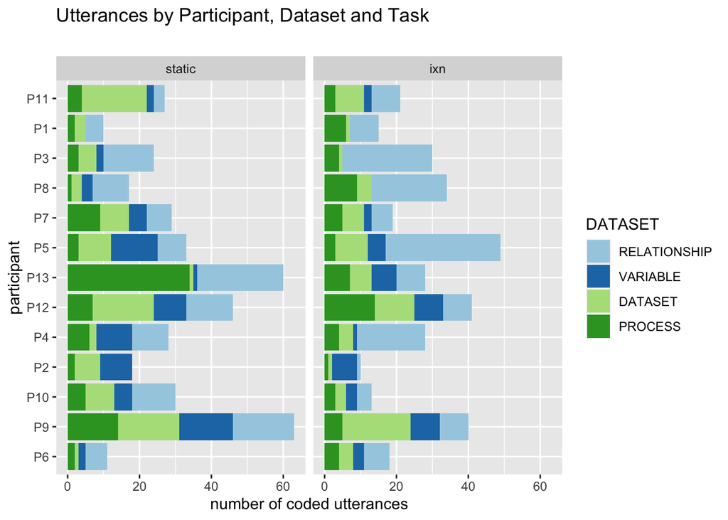

```r
#TOPICS by PARTICPANT facet TASK
gf_bar( PNUM ~., fill = ~ fct_rev(code_topic), data = df_coded) %>%
  gf_facet_grid(.~TASK) +
  scale_fill_brewer(type="qual", palette = 3) +
  labs(
    title = "Utterances by Participant, Dataset and Task",
    subtitle = "",
    x = "number of coded utterances",
    y = "participant",
    fill = "DATASET"
  )
```

```r
# #TOPICS by PARTICPANT facet TASK
# gf_bar( PNUM ~., fill = ~ fct_rev(code_topic), data = df_coded) %>%
#   gf_facet_grid(DATASET~TASK) +
#   scale_fill_brewer(type="qual", palette = 3) +
#   labs(
#     title = "Utterances by Participant, Dataset and Task",
#     subtitle = "",
#     x = "number of coded utterances",
#     y = "participant",
#     fill = "DATASET"
#   )
```

## 3.4 by TIME

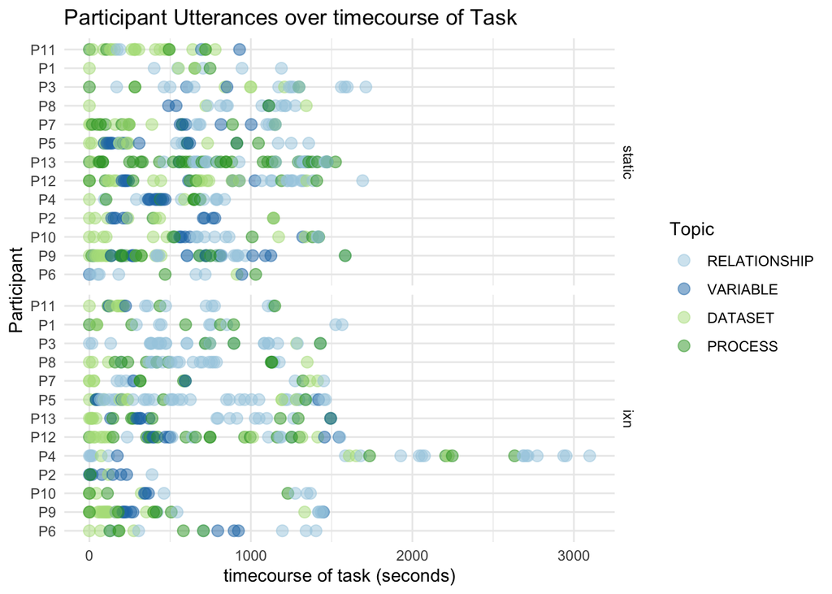

```r
#DOTPLOT
ggplot(df_time, aes(x=rel_time, y = PNUM, color=fct_rev(code_topic))) +
  geom_point(alpha=0.5, size=3) +
  facet_grid(df_time$TASK) +
  scale_color_brewer(type="qual", palette = 3) +
  theme_minimal() + labs(
    title = "Participant Utterances over timecourse of Task",
    x= "timecourse of task (seconds)", y = "Participant",
    color = "Topic"
  )
```

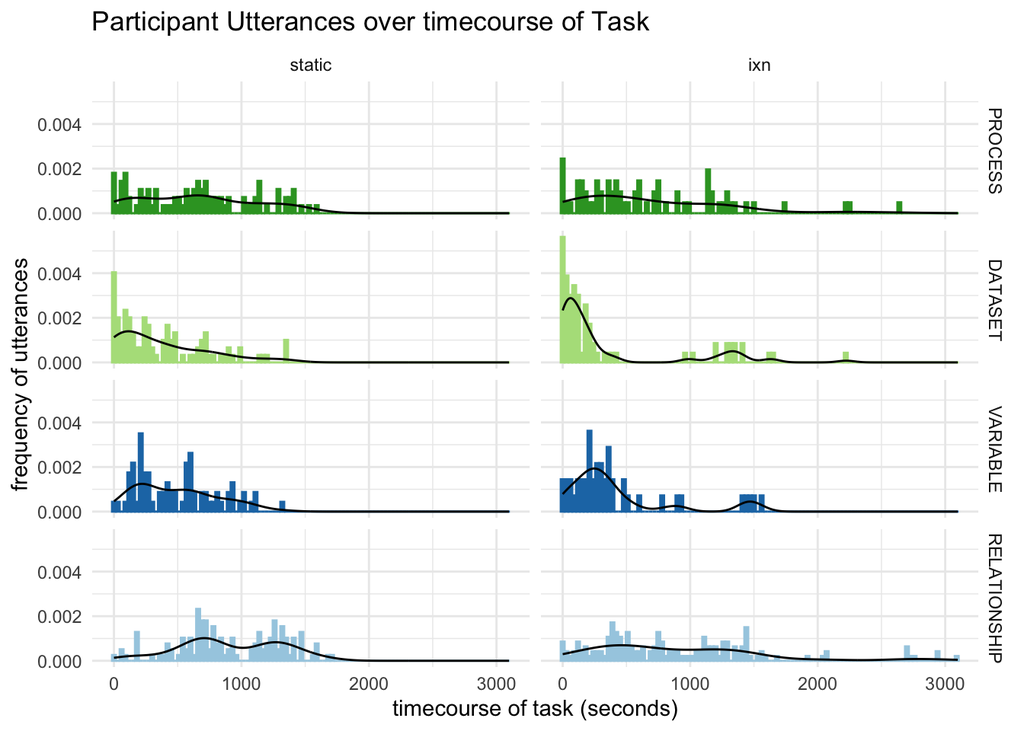

```r
#HISTOGRAMS BY TASK
ggplot(df_time, aes(x = rel_time)) +
  geom_histogram(binwidth = 30,aes(y=..density.., fill = fct_rev(code_topic), color = fct_rev(code_topic))) +
  geom_density()+
  facet_grid(df_time$code_topic ~ df_time$TASK) +
  scale_fill_brewer(type="qual", palette = 3) +
  scale_color_brewer(type="qual", palette = 3) +
  theme_minimal() + labs(
    title = "Participant Utterances over timecourse of Task",
    x= "timecourse of task (seconds)", y = "frequency of utterances",
    fill = "Topic"
  ) + theme_minimal() + theme(legend.position = "blank")
```